# Practical Machine Learning Course Report

Kadri Umay

February 9, 2016

## Introduction

Using devices such as Jawbone Up, Nike FuelBand, and Fitbit it is now possible to collect a large amount of data about personal activity relatively inexpensively. These type of devices are part of the quantified self movement â a group of enthusiasts who take measurements about themselves regularly to improve their health, to find patterns in their behavior, or because they are tech geeks. One thing that people regularly do is quantify how much of a particular activity they do, but they rarely quantify how well they do it. In this project, your goal will be to use data from accelerometers on the belt, forearm, arm, and dumbell of 6 participants. They were asked to perform barbell lifts correctly and incorrectly in 5 different ways. More information is available from the website here: http://groupware.les.inf.puc-rio.br/har (see the section on the Weight Lifting Exercise Dataset).

The approach proposed for the Weight Lifting Exercises dataset is to investigate “how (well)” an activity was performed by the wearer. The “how (well)” investigation provides useful information for a large variety of applications,such as sports training.

The quality of execution is defined for Unilateral Dumbbell Biceps Curl in five different fashions. Class A corresponds to the specified execution of the exercise, while the other 4 classes correspond to common mistakes. * A - Exactly according to the specification * B - Throwing the elbows to the front * C - Lifting the dumbbell only halfway * D - Lowering the dumbbell only halfway * E - Throwing the hips to the front

We will try to classify the quality of exeuction in one of the 5 different classes based on the data collected from the on-body sensors while the exercises were performed by six male participants aged between 20-28 years, with little weight lifting experience and simulating the mistakes.

Read more: http://groupware.les.inf.puc-rio.br/har#ixzz3z1Cxz0oe

## Data Preprocessing

```r
library(caret)
```

```r
library(rpart)
library(rpart.plot)
library(randomForest)
library(corrplot)
library(nnet)
library(e1071)
library(MASS)
```

### Set Directories and Download Data

Download Data and store in data frames

```r
ProjectDir <- "c:\\users\\kadriu\\documents\\GitHub\\Coursera-Practical-Machine-Learning"
SubDir <- "Data"
setwd(ProjectDir)

if (!file.exists(SubDir)) {
  dir.create(file.path(SubDir))
}
setwd(file.path(ProjectDir, SubDir))

TrainLink <- "http://d396qusza40orc.cloudfront.net/predmachlearn/pml-training.csv"
TestLink <- "http://d396qusza40orc.cloudfront.net/predmachlearn/pml-testing.csv"
TrainFile <- "pml-training.csv"
TestFile <- "pml-testing.csv"
if (!file.exists(TrainFile))
  download.file(TrainLink, destfile = TrainFile, method = "curl")
if (!file.exists(TestFile))
  download.file(TestLink, destfile = TestFile, method = "curl")

RawTrainData <- read.csv(TrainFile)
RawTestData <- read.csv(TestFile)
```

Raw Training Data Summary The ‘classe’ variable in the dataset is the variable to predict

Number of Variables

```r
dim(RawTrainData) #19622 160
```

```
## [1] 19622   160
```

```r
str(RawTrainData, list.len=ncol(RawTrainData))
```

```
## 'data.frame':    19622 obs. of  160 variables:
##  $ X                       : int  1 2 3 4 5 6 7 8 9 10 ...
##  $ user_name               : Factor w/ 6 levels "adelmo","carlitos",..: 2 2 2 2 2 2 2 2 2 2 ...
##  $ raw_timestamp_part_1    : int  1323084231 1323084231 1323084231 1323084232 1323084232 1323084232 1323084232 1323084232 1323084232 1323084232 ...
##  $ raw_timestamp_part_2    : int  788290 808298 820366 120339 196328 304277 368296 440390 484323 484434 ...
##  $ cvtd_timestamp          : Factor w/ 20 levels "02/12/2011 13:32",..: 9 9 9 9 9 9 9 9 9 9 ...
##  $ new_window              : Factor w/ 2 levels "no","yes": 1 1 1 1 1 1 1 1 1 1 ...
##  $ num_window              : int  11 11 11 12 12 12 12 12 12 12 ...
##  $ roll_belt               : num  1.41 1.41 1.42 1.48 1.48 1.45 1.42 1.42 1.43 1.45 ...
##  $ pitch_belt              : num  8.07 8.07 8.07 8.05 8.07 8.06 8.09 8.13 8.16 8.17 ...
##  $ yaw_belt                : num  -94.4 -94.4 -94.4 -94.4 -94.4 -94.4 -94.4 -94.4 -94.4 -94.4 ...
##  $ total_accel_belt        : int  3 3 3 3 3 3 3 3 3 3 ...
##  $ kurtosis_roll_belt      : Factor w/ 397 levels "","-0.016850",..: 1 1 1 1 1 1 1 1 1 1 ...
##  $ kurtosis_picth_belt     : Factor w/ 317 levels "","-0.021887",..: 1 1 1 1 1 1 1 1 1 1 ...
##  $ kurtosis_yaw_belt       : Factor w/ 2 levels "","#DIV/0!": 1 1 1 1 1 1 1 1 1 1 ...
```

[output cut: 146 more lines]

Raw Test Data Summary Number of Rows

```r
dim(RawTestData) #20 160
```

```
## [1]  20 160
```

```r
str(RawTestData, list.len=ncol(RawTestData))
```

```
## 'data.frame':    20 obs. of  160 variables:
##  $ X                       : int  1 2 3 4 5 6 7 8 9 10 ...
##  $ user_name               : Factor w/ 6 levels "adelmo","carlitos",..: 6 5 5 1 4 5 5 5 2 3 ...
##  $ raw_timestamp_part_1    : int  1323095002 1322673067 1322673075 1322832789 1322489635 1322673149 1322673128 1322673076 1323084240 1322837822 ...
##  $ raw_timestamp_part_2    : int  868349 778725 342967 560311 814776 510661 766645 54671 916313 384285 ...
##  $ cvtd_timestamp          : Factor w/ 11 levels "02/12/2011 13:33",..: 5 10 10 1 6 11 11 10 3 2 ...
##  $ new_window              : Factor w/ 1 level "no": 1 1 1 1 1 1 1 1 1 1 ...
##  $ num_window              : int  74 431 439 194 235 504 485 440 323 664 ...
##  $ roll_belt               : num  123 1.02 0.87 125 1.35 -5.92 1.2 0.43 0.93 114 ...
##  $ pitch_belt              : num  27 4.87 1.82 -41.6 3.33 1.59 4.44 4.15 6.72 22.4 ...
##  $ yaw_belt                : num  -4.75 -88.9 -88.5 162 -88.6 -87.7 -87.3 -88.5 -93.7 -13.1 ...
##  $ total_accel_belt        : int  20 4 5 17 3 4 4 4 4 18 ...
##  $ kurtosis_roll_belt      : logi  NA NA NA NA NA NA ...
##  $ kurtosis_picth_belt     : logi  NA NA NA NA NA NA ...
##  $ kurtosis_yaw_belt       : logi  NA NA NA NA NA NA ...
```

[output cut: 146 more lines]

Check the rows of data which has complete cases Training Dataset

```r
sum(complete.cases(RawTrainData)) #406 Very small part of the training data has complete data
```

```
## [1] 406
```

Test Dataset

```r
sum(complete.cases(RawTestData)) #0 None of the test data has complete data
```

```
## [1] 0
```

### Data Cleaning and Preperation

We will remove the NAs and irrelevant variables

In the training set check columns with total NA values greater then 10% of the rows (more than 2000 NAs)

```r
RawTrainDataNZero <- RawTrainData[, colSums(is.na(RawTrainData)) < 2000]
ncol(RawTrainDataNZero) #93
```

```
## [1] 93
```

Check the numbers of columns which has one or more NAs

```r
RawTrainDataZero <- RawTrainData[, colSums(is.na(RawTrainData)) == 0]
ncol(RawTrainDataZero) #93
```

```
## [1] 93
```

Again 93 columns have no NAs, no need for further detailed processing such as imputing Just remove the columns with NAs

```r
RawTrainData <- RawTrainData[, colSums(is.na(RawTrainData)) == 0]
```

```r
RawTestData <- RawTestData[, colSums(is.na(RawTestData)) == 0]
```

Further to this, we need to remove the unnecessary columns that do not contribute to the results

These are: $X:int $user_name:Factor w / 6 levels $raw_timestamp_part_1:int $raw_timestamp_part_2:int $cvtd_timestamp:Factor w / 20 levels $new_window:Factor w / 2 levels $num_window:int

```r
classe <- RawTrainData$classe
TrainColsToRemove <- grepl("^X|user_name|timestamp|window", names(RawTrainData))
RawTrainData <- RawTrainData[, !TrainColsToRemove]
CleanTrainData <- RawTrainData[, sapply(RawTrainData, is.numeric)]
CleanTrainData$classe <- classe

classe <- RawTestData$classe
TestColsToRemove <- grepl("^X|user_name|timestamp|window", names(RawTestData))
RawTestData <- RawTestData[, !TestColsToRemove]
CleanTestData <- RawTestData[, sapply(RawTestData, is.numeric)]
CleanTestData$classe <- classe
```

Check the rows of data which has complete cases again Training Dataset

```r
sum(complete.cases(RawTrainData)) #19622 We do now have complete cases for all training data
```

```
## [1] 19622
```

Test Dataset

```r
sum(complete.cases(RawTestData)) #20 We do now have complete cases for all test data
```

```
## [1] 20
```

Set seed for reproducible results

```r
set.seed(562389)
```

We further the partition the training dataset for training and validataion purposes. We would like to the validate the model with a subset of the data before applying the test data This is to avoid overfitting Generate a training and validation dataset

```r
TrainIdx <- createDataPartition(CleanTrainData$classe, p = 0.7, list = FALSE)
TrainData <- CleanTrainData[TrainIdx,]
TestData <- CleanTrainData[ - TrainIdx,]
```

## Data Modelling

We will test several algorithms and compare their accuracy levels

### First one is the Random Forest

```r
modelRf <- randomForest(classe~., data = TrainData)
predRf<-predict(modelRf,TestData)
confusionMatrix(TestData$classe, predRf)
```

```
## Confusion Matrix and Statistics
##
##           Reference
## Prediction    A    B    C    D    E
##          A 1673    1    0    0    0
##          B    5 1134    0    0    0
##          C    0    6 1017    3    0
##          D    0    0    7  956    1
##          E    0    0    2    1 1079
##
## Overall Statistics
##
##                Accuracy : 0.9956
##                  95% CI : (0.9935, 0.9971)
##     No Information Rate : 0.2851
##     P-Value [Acc > NIR] : < 2.2e-16
##
##                   Kappa : 0.9944
##  Mcnemar's Test P-Value : NA
##
## Statistics by Class:
##
##                      Class: A Class: B Class: C Class: D Class: E
## Sensitivity            0.9970   0.9939   0.9912   0.9958   0.9991
## Specificity            0.9998   0.9989   0.9981   0.9984   0.9994
## Pos Pred Value         0.9994   0.9956   0.9912   0.9917   0.9972
## Neg Pred Value         0.9988   0.9985   0.9981   0.9992   0.9998
## Prevalence             0.2851   0.1939   0.1743   0.1631   0.1835
## Detection Rate         0.2843   0.1927   0.1728   0.1624   0.1833
## Detection Prevalence   0.2845   0.1935   0.1743   0.1638   0.1839
## Balanced Accuracy      0.9984   0.9964   0.9947   0.9971   0.9992
```

### Second we test Artificial Neural Network

```r
modelNn <- nnet(classe~., data = TrainData, size=15)
predNn<-predict(modelNn,TestData, TYPE="class")
```

Output of predictors for Artifical Neural Networks is different Rather then giving the highhest probability prediction It gives the probability for each prediction We select the one with the highest

```r
prdNN<-c("A","B","C","D","E")[apply(predNn,1,which.max)]
confusionMatrix(TestData$classe, prdNN)
```

```
## Confusion Matrix and Statistics
##
##           Reference
## Prediction    A    B    C    D    E
##          A 1069  104  235  227   39
##          B  120  543  146  168  162
##          C  179   94  538  146   69
##          D  106  109   98  531  120
##          E  104  241  187  256  294
##
## Overall Statistics
##
##                Accuracy : 0.5055
##                  95% CI : (0.4927, 0.5184)
##     No Information Rate : 0.2681
##     P-Value [Acc > NIR] : < 2.2e-16
##
##                   Kappa : 0.3771
##  Mcnemar's Test P-Value : < 2.2e-16
##
## Statistics by Class:
##
##                      Class: A Class: B Class: C Class: D Class: E
## Sensitivity            0.6774  0.49771  0.44684  0.39985  0.42982
## Specificity            0.8595  0.87568  0.89575  0.90498  0.84849
## Pos Pred Value         0.6386  0.47673  0.52437  0.55083  0.27172
## Neg Pred Value         0.8791  0.88453  0.86293  0.83804  0.91880
## Prevalence             0.2681  0.18539  0.20459  0.22566  0.11623
## Detection Rate         0.1816  0.09227  0.09142  0.09023  0.04996
## Detection Prevalence   0.2845  0.19354  0.17434  0.16381  0.18386
## Balanced Accuracy      0.7685  0.68669  0.67130  0.65242  0.63916
```

### Third we test support vector algorithm

```r
modelSvm <- svm(classe~., data = TrainData)
predSvm<-predict(modelSvm,TestData)
confusionMatrix(TestData$classe, predSvm)
```

```
## Confusion Matrix and Statistics
##
##           Reference
## Prediction    A    B    C    D    E
##          A 1670    0    2    0    2
##          B   84 1039   16    0    0
##          C    0   30  978   12    6
##          D    6    0   87  870    1
##          E    0   10   24   17 1031
##
## Overall Statistics
##
##                Accuracy : 0.9495
##                  95% CI : (0.9436, 0.955)
##     No Information Rate : 0.2991
##     P-Value [Acc > NIR] : < 2.2e-16
##
##                   Kappa : 0.936
##  Mcnemar's Test P-Value : NA
##
## Statistics by Class:
##
##                      Class: A Class: B Class: C Class: D Class: E
## Sensitivity            0.9489   0.9629   0.8835   0.9677   0.9913
## Specificity            0.9990   0.9792   0.9900   0.9811   0.9895
## Pos Pred Value         0.9976   0.9122   0.9532   0.9025   0.9529
## Neg Pred Value         0.9786   0.9916   0.9735   0.9941   0.9981
## Prevalence             0.2991   0.1833   0.1881   0.1528   0.1767
## Detection Rate         0.2838   0.1766   0.1662   0.1478   0.1752
## Detection Prevalence   0.2845   0.1935   0.1743   0.1638   0.1839
## Balanced Accuracy      0.9739   0.9711   0.9367   0.9744   0.9904
```

### Fourth we would like to test Linear Discriminant Analysis for its simplicity

```r
modelLda <- lda(classe~., data = TrainData)
predLda<-predict(modelLda,TestData)
confusionMatrix(TestData$classe, predLda$class)
```

```
## Confusion Matrix and Statistics
##
##           Reference
## Prediction    A    B    C    D    E
##          A 1360   34  140  137    3
##          B  174  731  144   36   54
##          C   99  107  669  115   36
##          D   56   47  109  708   44
##          E   31  170   95  103  683
##
## Overall Statistics
##
##                Accuracy : 0.7054
##                  95% CI : (0.6935, 0.717)
##     No Information Rate : 0.2923
##     P-Value [Acc > NIR] : < 2.2e-16
##
##                   Kappa : 0.6273
##  Mcnemar's Test P-Value : < 2.2e-16
##
## Statistics by Class:
##
##                      Class: A Class: B Class: C Class: D Class: E
## Sensitivity            0.7907   0.6713   0.5782   0.6442   0.8329
## Specificity            0.9246   0.9149   0.9245   0.9465   0.9212
## Pos Pred Value         0.8124   0.6418   0.6520   0.7344   0.6312
## Neg Pred Value         0.9145   0.9246   0.8996   0.9205   0.9715
## Prevalence             0.2923   0.1850   0.1966   0.1867   0.1393
## Detection Rate         0.2311   0.1242   0.1137   0.1203   0.1161
## Detection Prevalence   0.2845   0.1935   0.1743   0.1638   0.1839
## Balanced Accuracy      0.8577   0.7931   0.7514   0.7954   0.8771
```

Note that the output of predictor is also different in this case, we need to select the class variable

### Fifth and last one is the regression tree

Which are useful for their human interpretable results

```r
modelCart <- rpart(classe~., data = TrainData)
predCart<-predict(modelCart,TestData)
```

Output of predictors for Classification and Regression Tree is different Rather then giving the highhest probability prediction It gives the probability for each prediction We select the one with the highest

```r
prdCART<-c("A","B","C","D","E")[apply(predCart,1,which.max)]
confusionMatrix(TestData$classe, prdCART)
```

```
## Confusion Matrix and Statistics
##
##           Reference
## Prediction    A    B    C    D    E
##          A 1510   38   66   42   18
##          B  256  694  103   58   28
##          C   27  144  794   53    8
##          D   96   43  179  597   49
##          E   35   54   91   70  832
##
## Overall Statistics
##
##                Accuracy : 0.7523
##                  95% CI : (0.741, 0.7632)
##     No Information Rate : 0.3269
##     P-Value [Acc > NIR] : < 2.2e-16
##
##                   Kappa : 0.685
##  Mcnemar's Test P-Value : < 2.2e-16
##
## Statistics by Class:
##
##                      Class: A Class: B Class: C Class: D Class: E
## Sensitivity            0.7848   0.7133   0.6440   0.7280   0.8898
## Specificity            0.9586   0.9094   0.9501   0.9275   0.9495
## Pos Pred Value         0.9020   0.6093   0.7739   0.6193   0.7689
## Neg Pred Value         0.9017   0.9412   0.9097   0.9547   0.9786
## Prevalence             0.3269   0.1653   0.2095   0.1393   0.1589
## Detection Rate         0.2566   0.1179   0.1349   0.1014   0.1414
## Detection Prevalence   0.2845   0.1935   0.1743   0.1638   0.1839
## Balanced Accuracy      0.8717   0.8113   0.7970   0.8278   0.9197
```

## Results of the comparision of accuracy of the different algorithms

```r
OutputTable <- c("Random Forest",as.numeric(confusionMatrix(TestData$classe, predRf)$overall["Accuracy"]))
temp<- rbind(OutputTable, c("Artificial Neural Network",as.numeric(confusionMatrix(TestData$classe, prdNN)$overall["Accuracy"])))
temp<- rbind(temp, c("Support Vector",as.numeric(confusionMatrix(TestData$classe, predSvm)$overall["Accuracy"])))
temp<- rbind(temp, c("Linear Discriminant Analysis",as.numeric(confusionMatrix(TestData$classe, predLda$class)$overall["Accuracy"])))
temp<- rbind(temp, c("Classification and Regression Tree",as.numeric(confusionMatrix(TestData$classe, prdCART)$overall["Accuracy"])))
OutputTable <- temp
colnames(OutputTable) <- c("Algorithm", "Accuracy")
OutputTable
```

```
##             Algorithm                            Accuracy
## OutputTable "Random Forest"                      "0.995581988105353"
##             "Artificial Neural Network"          "0.505522514868309"
##             "Support Vector"                     "0.949532710280374"
##             "Linear Discriminant Analysis"       "0.7053525913339"
##             "Classification and Regression Tree" "0.752251486830926"
```

By far random forest is the most acurate one We will use this algorithm for predicting the outcome for the course project

```r
predRf<-predict(modelRf,CleanTestData)
predRf
```

```
##  1  2  3  4  5  6  7  8  9 10 11 12 13 14 15 16 17 18 19 20
##  B  A  B  A  A  E  D  B  A  A  B  C  B  A  E  E  A  B  B  B
## Levels: A B C D E
```

## Visual Analysis of the Model

An additional tree visualization would reveal the Decision critieria Especialy important to be analyzed by a domain expert Sometime data driven models could bring some issues

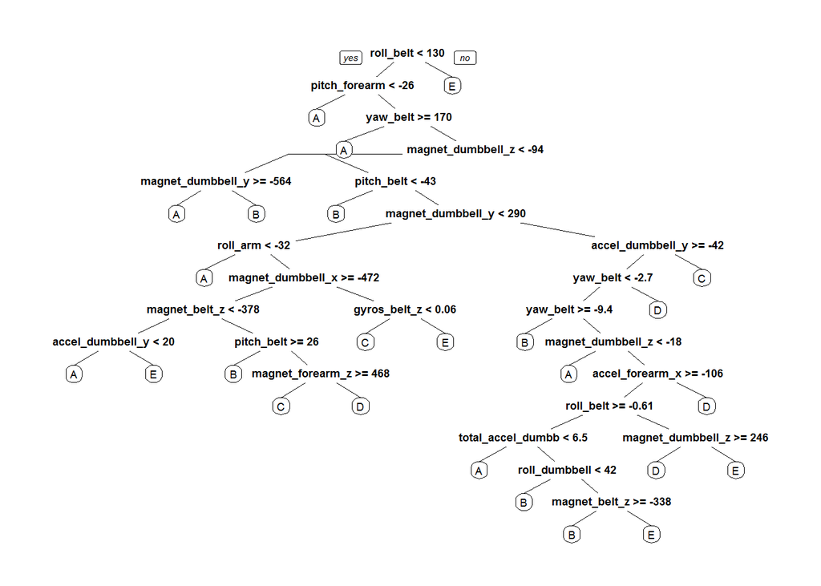

```r
treeModel <- rpart(classe ~ ., data=TrainData, method="class")
prp(treeModel)
```

Correlation Plot between different attributes of the model The graph is not readable but gives an idea on the importance of some of the attributes of the model

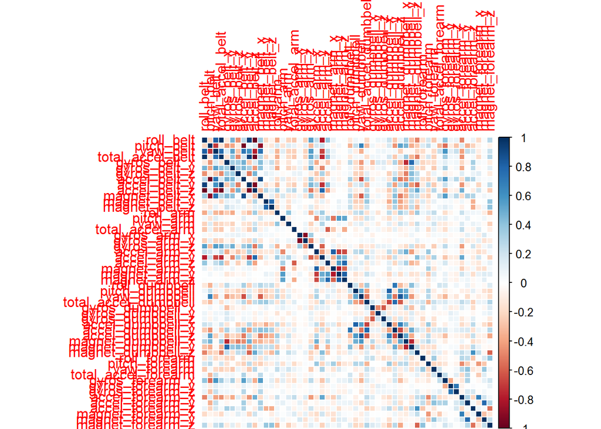

```r
corrPlot <- cor(TrainData[, -length(names(TrainData))])
corrplot(corrPlot, method="color")
```